# **Two simple approaches to prediction: Least Squares and Nearest Neighbors**

This post follows Chapter 2.3 in the [Elements of Statistical Learning](http://statweb.stanford.edu/~tibs/ElemStatLearn/). Note that the data for exactly reproducing the figures in the book are available in `mixture.example` from the R package `ElemStatLearn`, but here I’ll be going through the example from scratch.

This section develops the *linear model fit by least squares* and the *$\textbf{k}$-nearest neighbor (kNN)* prediction methods. The linear model makes large assumptions about the structure of the data, and yields stable but possibly inaccurate predictions (i.e., it is a relatively ‘inflexible’, or high-bias/low-variance prediction method). The kNN method makes mild structural assumptions– its predictions are often accurate but can be unstable (i.e., it is a relatively ‘flexible’, or low-bias/high-variance prediction method).

First, I generate training data from a Gaussian mixture model as described in section 2.3.3:

> First, we generated 10 means $m_k$ from a bivariate Gaussian distribution $N((1,0)^T, \mathbf{I})$ and labeled this class $\color{cornflowerblue}{\texttt{BLUE}}$. Similarly, 10 more were drawn from $N((0,1)^T, \mathbf{I})$ and labeled class $\color{darkorange}{\texttt{ORANGE}}$. Then for each class we generated 100 observations as follows: for each observation, we picked an $m_k$ at random with probability $1/10$, and then generated a $N(m_k, \mathbf{I}/5)$, thus leading to a mixture of Gaussian clusters for each class.

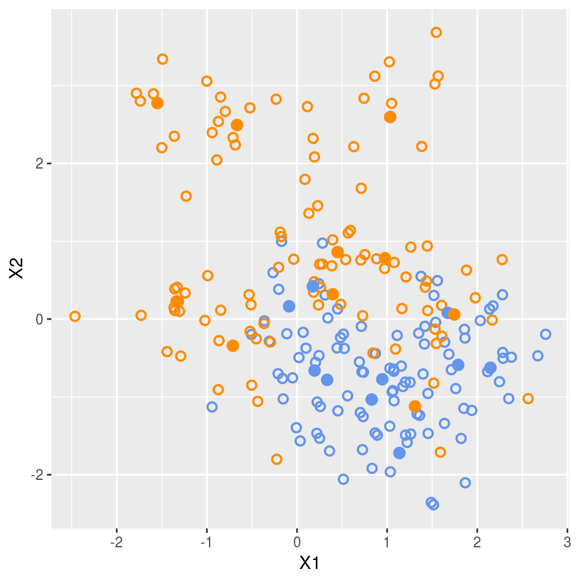

The training data. Filled points represent the means $m_k$ of the Gaussians used to generate each class.

```r
library(MASS)
library(tibble)
library(reshape2)
library(ggplot2)
library(mvtnorm)

#a function to generate data as in ESL 2.3.3
#npoints = points to generate PER COLOR
oracle = function(npoints){
  #set mean vectors for blue and orange m_k:
  blue.mu = c(1,0)
  og.mu = c(0,1)

  #choose m_k for blue and orange
  blue.means = as_data_frame(mvrnorm(n=10, mu=blue.mu, Sigma=diag(2)))
  blue.means$color = factor(rep(0,nrow(blue.means)), levels = c(0,1), labels = c("BLUE", "ORANGE"))
  og.means = as_data_frame(mvrnorm(n=10, mu=og.mu, Sigma=diag(2)))
  og.means$color = factor(rep(1, nrow(og.means)), levels = c(0,1), labels = c("BLUE", "ORANGE"))

  #randomly choose npoints number of m_k for blue and orange
  blue.randmean = blue.means[sample(1:nrow(blue.means),npoints, replace = TRUE),1:2]
  og.randmean = og.means[sample(1:nrow(og.means),npoints, replace = TRUE),1:2]

  #generate datapoints from MVrandom normal with means chosen above
  blue.data = as_data_frame(t(apply(blue.randmean, MARGIN=1, function(x) mvrnorm(n=1, mu=x, Sigma=diag(2)/5))))
  og.data = as_data_frame(t(apply(og.randmean, MARGIN=1, function(x) mvrnorm(n=1, mu=x, Sigma=diag(2)/5))))
  blue.data$color = factor(rep(0, nrow(blue.data)), levels = c(0,1), labels = c("BLUE", "ORANGE"))
  og.data$color = factor(rep(1, nrow(og.means)), levels = c(0,1), labels = c("BLUE", "ORANGE"))

  #return plotdata, a dataframe containing training data
  #return meandata, a dataframe containing the generating m_k
  return(list(plotdata = rbind(blue.data, og.data), meandata = rbind(blue.means, og.means)))
}

#generate training data wih 100 points of each color
train = oracle(100)

#plot training data
(a = ggplot() +
      geom_point(data = train$plotdata, aes(x=V1, y=V2, color=color), shape=21, size=2, stroke=1) +
      geom_point(data = train$meandata, aes(x=V1, y=V2, color=color), size=3) +
      scale_color_manual(values= c("#6495ED","#FF8C00"), guide=FALSE) +
      xlab("X1") + ylab("X2"))
```

## **predict using linear regression**

Two-class classification problem. Denote the binary coded target as $Y$, and treat it as a quantitative output. Predictions $\hat Y$ will typically lie in $[0,1]$, and we can assign $\hat G$ the class label according to whether $\hat y > 0.5$.

Linear model:
$$\hat Y = X^T \hat \beta$$
Use method of least squares to fit $\hat \beta$ by minimizing the residual sum of squares:
$$\text{RSS}(\beta) = \sum_{i=1}^N (y_i - x_i^T \beta)^2$$
$\text{RSS}(\beta)$ is a quadratic function, and hence its minimum always exists, though it may not be unique. The solution is easiest to characterize in matrix notation:
$$\text{RSS}(\beta) = (\mathbf{y}- \mathbf{X} \beta)^T (\mathbf{y} - \mathbf{X} \beta)$$
, where $\mathbf{X} \in \mathbb{R}^{N \times p}$ with each row an input vector, and $\mathbf{y} \in \mathbb{R}^N$ representing the outputs in the training set. Differentiating w.r.t. $\beta$ we get the *normal equations*:
$$\mathbf{X}^T(\mathbf{y} - \mathbf{X}\beta) = 0$$
If $\mathbf{X}^T\mathbf{X}$ is nonsingular, then the unique solution is given by
$$\hat\beta = (\mathbf{X}^T \mathbf{X})^{-1} \mathbf{X}^T \mathbf{y}$$
, and the fitted value at the $i$th input $x_i$ is $\hat y_i = \hat y(x_i) = x_i^T \hat \beta$. At an arbitrary input $x_0$ the prediction is $\hat y(x_0) = x_0^T \hat \beta$. The entire fitted surface is characterized by the $p$ parameters $\hat \beta$.

Encode the output class variable $G$, which can take on the values $\color{cornflowerblue}{\texttt{BLUE}}$ or $\color{darkorange}{\texttt{ORANGE}}$, and encode it as a response $Y$ where $0$ is $\color{cornflowerblue}{\texttt{BLUE}}$ and $1$ is $\color{darkorange}{\texttt{ORANGE}}$. Then convert the fitted values $\hat Y$ to a fitted class variable $\hat G$ according to the rule:
$$\hat G = \begin{cases}
\color{darkorange}{\texttt{ORANGE}} & \text{if } \hat Y > 0.5 \\
\color{cornflowerblue}{\texttt{BLUE}} & \text{if } \hat Y \leq 0.5
\end{cases}$$

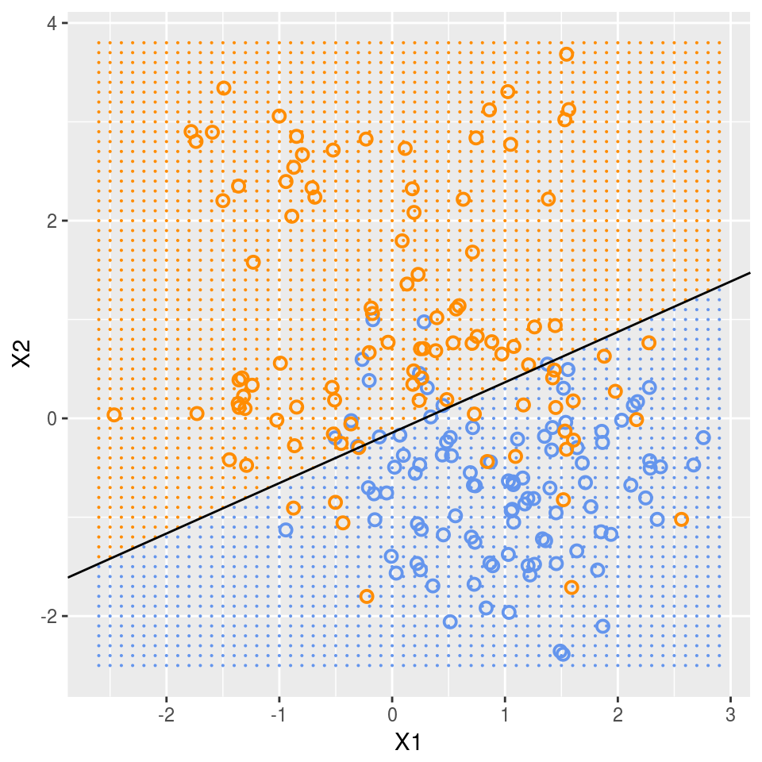

Classification by linear regression. The orange shaded region represents points that will be classified as $\color{darkorange}{\texttt{ORANGE}}$, while the blue region will be classified as $\color{cornflowerblue}{\texttt{BLUE}}$

```r
X = as.matrix(cbind(rep(1, nrow(train$plotdata)), train$plotdata[,-3]))
y = ifelse(train$plotdata$color=="ORANGE", 1, 0)

#my linear model function
mylm = function(X,y){
  return(beta.hat = solve(t(X) %*% X) %*% t(X) %*% y)
}

beta.hat = mylm(X,y)

#set ranges for grid based on ranges of training data
x.min = round(min(train$plotdata$V1), digits=1)-0.1
x.max = round(max(train$plotdata$V1), digits=1)+0.1
y.min = round(min(train$plotdata$V2), digits=1)-0.1
y.max = round(max(train$plotdata$V2), digits=1)+0.1

x.range = seq(from=x.min, to=x.max, by=0.1)
y.range = seq(from=y.min, to=y.max, by=0.1)

x.new = expand.grid(x.range, y.range)
names(x.new) = names(train$plotdata[,-3])

#predict grid using linear model
linreg.yhat = as.matrix(cbind(rep(1, nrow(x.new)), x.new)) %*% beta.hat
linreg.pred = ifelse(linreg.yhat>0.5,"ORANGE","BLUE")
linreg.plotdata = cbind(x.new, linreg.pred)

#plot linear model classification
(b = ggplot() +
      geom_point(data = linreg.plotdata, aes(x=V1, y=V2, color=linreg.pred), size=0.05) +
      geom_point(data = train$plotdata, aes(x=V1, y=V2, color=color), shape=21, size=2, stroke=1) +
      geom_abline(slope = -beta.hat[2]/beta.hat[3], intercept = (.5-beta.hat[1])/beta.hat[3], color="black") +
      scale_color_manual(values= c("#6495ED","#FF8C00"), guide=FALSE) +
      xlab("X1") + ylab("X2"))
```

Because in this case we know the generating function of the distribution, we can find the Bayes-optimal decision boundary, which says that we simply classify to the class which was most likely to have generated the data point:
$$\hat G(x) = \max_{g \in G} \text{Pr}(g \mid X=x)$$
. In R, this amounts to summing the probabilities of a point being generated by the multivariate normal distributions centered at the $\color{cornflowerblue}{\texttt{BLUE }} m_k$, summing the probabilities of a point being generated by the multivariate normal distributions centered at the $\color{darkorange}{\texttt{ORANGE }} m_k$, and classifying to the class with the higher probability.

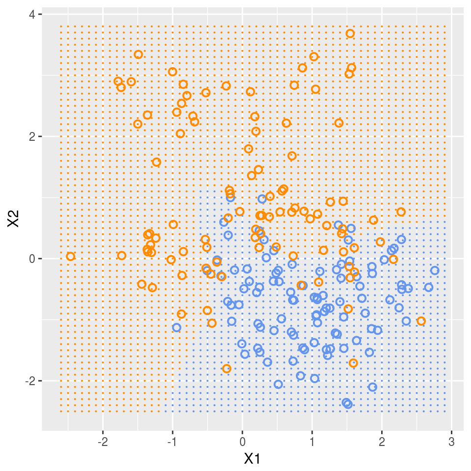

The optimal Bayes decision boundary.

```r
mybayes = function(xnew,means){
  bayes.df = data_frame(pblue=numeric(nrow(xnew)), pog=numeric(nrow(xnew)))
  for (i in 1:10){
    bayes.df$pblue = bayes.df$pblue + dmvnorm(x=xnew, mean=as.vector(as.numeric(means[i,1:2])), sigma = diag(2)/5)
    bayes.df$pog = bayes.df$pog + dmvnorm(x=xnew, mean=as.vector(as.numeric(means[i+10,1:2])), sigma = diag(2)/5)
  }
  bayes.df$prediction = ifelse(bayes.df$pog>bayes.df$pblue, "ORANGE", "BLUE")
  bayes.plotdata = cbind(xnew, bayes.df$prediction)
  names(bayes.plotdata)[3] = "color"
  return(bayes.plotdata)
}
grid.bayes = mybayes(x.new, train$meandata)

(bayes.plot = ggplot() +
                geom_point(data = grid.bayes, aes(x=V1, y=V2, color=color), size=0.05) +
                geom_point(data = train$plotdata, aes(x=V1, y=V2, color=color), shape=21, size=2, stroke=1) +
                #geom_point(data = train$meandata, aes(x=V1, y=V2, color=color), size=4) +
                scale_color_manual(values= c("#6495ED","#FF8C00"), guide=FALSE) +
                xlab("X1") + ylab("X2"))
```

## **predict using nearest-neighbor methods**

The $k$-nearest neighbor fit for $\hat Y$ is defined as follows:
$$\hat Y (x) = \frac{1}{k} \sum_{x_i \in N_k(x)} y_i$$

, where $N_k(x)$ is the neighborhood of $x$ defined by the $k$ closest points $x_i$ in the training sample, defined by Euclidean distance. In words, to classify a new point, $k$NN finds the $k$ closest points in the training data (a neighborhood), and classifies to the most abundant class in the neighborhood.

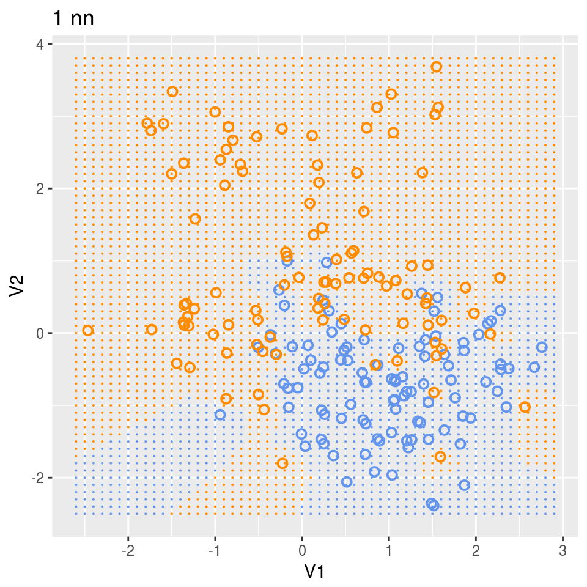

1-nearest neighbor classification.

```r
#knn classification function:
#   inputs: xnew- a matrix of new x values to be classified
#           x- matrix of training inputs
#           y- vector of training labels
#           k- # of nearest neighbors parameter
myknn = function(xnew, x, y, k){
  N.new = nrow(xnew)
  ynew = numeric(N.new)

  allpoints = rbind(xnew, x)
  dmatrix = as.matrix(dist(allpoints))[seq(N.new+1, nrow(allpoints)),seq(1, N.new)]
  rownames(dmatrix) = 1:length(y)

  for (i in 1:N.new){
    dist.vector = dmatrix[,i]
    dist.sorted = sort(dist.vector)
    nn.indices = as.numeric(names(dist.sorted[1:k]))
    ynew[i] = sum(y[nn.indices])/k
  }
  return(ynew)
}

#function for returning prediction error given predictions and labels
prediction.error = function(yhat, y){
  return(sum(diag((table(yhat,y)/length(y)) %*% matrix(c(0,1,1,0), ncol=2))))
}

#function for plotting knn
plotknn = function(k){
  knn.yhat = myknn(x.new, train$plotdata[,-3], y, k)
  knn.pred = ifelse(knn.yhat>0.5,"ORANGE","BLUE")
  knn.plotdata = as_data_frame(cbind(x.new, knn.pred))
  boundary.data = as_data_frame(cbind(x.new, knn.yhat))

  c = ggplot() +
        geom_point(data=knn.plotdata, aes(x=V1, y=V2, color=knn.pred), size=0.05) +
        geom_point(data=train$plotdata, aes(x=V1,y=V2, color=color), shape=21, size=2, stroke=1) +
        #geom_contour(data=boundary.data, aes(x=V1,y=V2,z=knn.yhat), bins=1, color="black") +
        scale_color_manual(values= c("#6495ED","#FF8C00"), guide=FALSE) +
        ggtitle(paste(k, "nn"))
  return(c)
}

(c = plotknn(k=1))
```

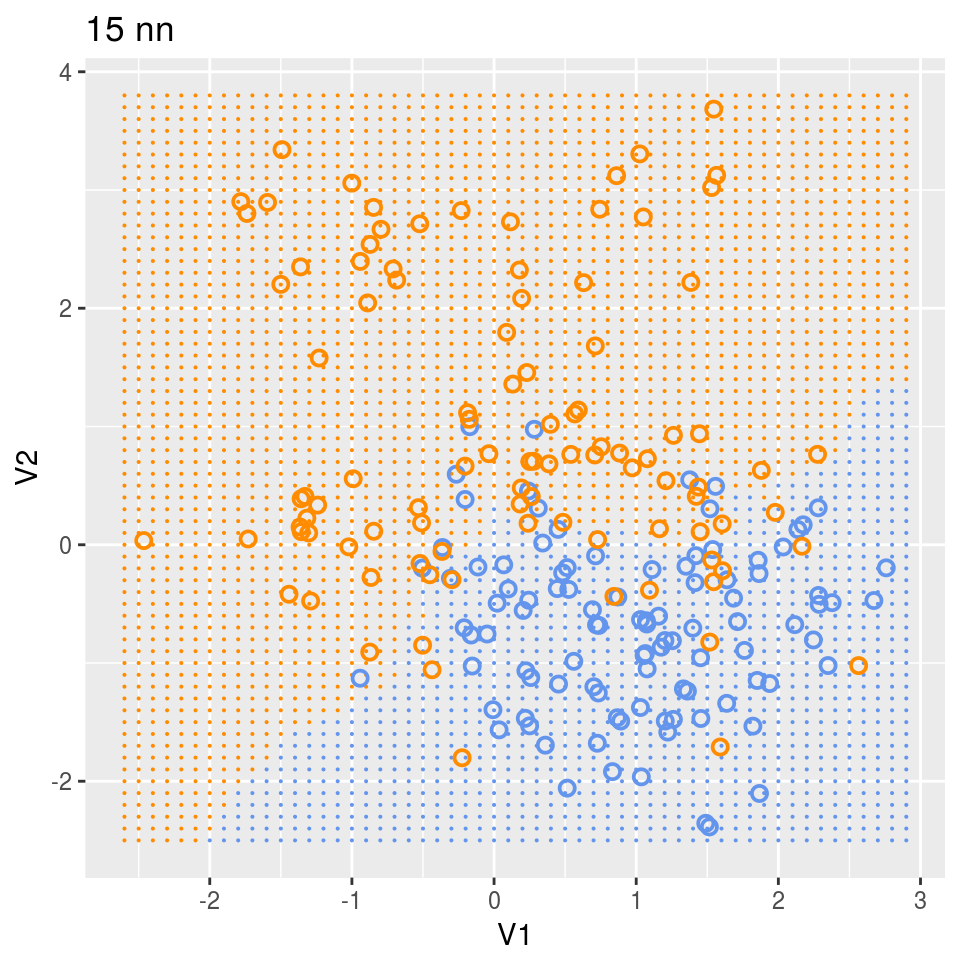

15-nearest neighbor classification.

```r
(d = plotknn(k=15))
```

The flexibility of kNN classification is a function of k (the effective degrees of freedom, and hence the flexibility, increases as k decreases). To try to find the optimal $k$, we can vary $k$ and measure classification accuracy on an independently generated test data set.

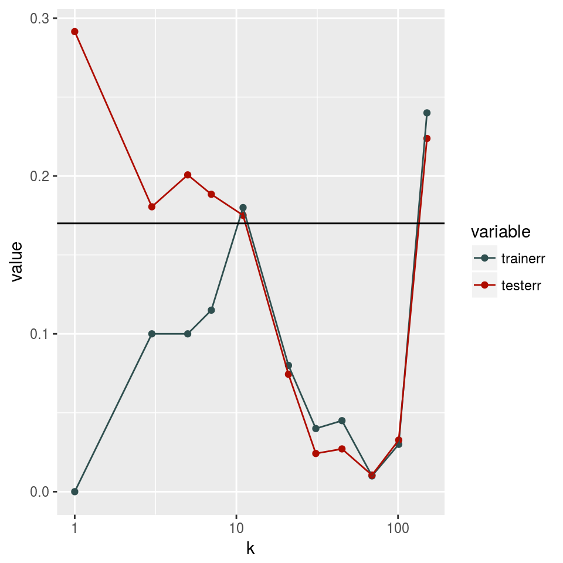

kNN training and test errors as a function of k. The Bayes-optimal error rate is in black.

```r
#calculate linear model training error
train.linreg.yhat = X %*% beta.hat
train.linreg.pred = ifelse(train.linreg.yhat>0.5, 1, 0)
linreg.trainerr = prediction.error(y, train.linreg.pred)

#generate test data
test = oracle(5000)

X.test = as.matrix(cbind(rep(1, nrow(test$plotdata)), test$plotdata[,-3]))
y.test = ifelse(test$plotdata$color=="ORANGE", 1, 0)

#predict on test data using linear model,
test.beta.hat = mylm(X.test, y.test)
test.linreg.yhat = X.test %*% test.beta.hat
test.linreg.pred = ifelse(test.linreg.yhat>0.5, 1, 0)
linreg.testerr = prediction.error(y.test, test.linreg.pred)

#calculate Bayes error
bayes.error = prediction.error(ifelse(mybayes(as_data_frame(X[,-1]), train$meandata)[,3]=="ORANGE",1,0 ), y)

#calculate training and test errors for KNN
kvector = c(1,3,5,7,11,21,31,45,69,101,151)
#kvector = c(1,5,10)

knn.error.df = data_frame(k = integer(), trainerr = double(), testerr = double())

rowcount = 1
for (k in kvector){
  knn.error.df[rowcount,1] = k
  knn.error.df[rowcount,2] = prediction.error(myknn(X[,-1], X[,-1], y, k), y)
  knn.error.df[rowcount,3] = prediction.error(myknn(X.test[,-1], X[,-1], y, k), y.test)
  rowcount = rowcount + 1
}

#plot error as function of k
(error.plot = ggplot(data = melt(knn.error.df, id.vars='k'), aes(x=k, y=value, group=variable, color=variable)) +
              geom_point() +
              geom_line() +
              scale_x_log10() +
              scale_color_manual(values = c("#2F4F4F","#AE0C00")) +
              geom_hline(yintercept = bayes.error)
)
```

As we decrease k, the bias of kNN classification decreases, while the variance increases. The tradeoff between these two causes test error to decrease and then increase again as k decreases.